# DRN Cell Types Project: Comparison with Dymecki Dataset (Okaty et al., 2015)

Kee Wui Huang, Sabatini Lab (Harvard Medical School)

22 August, 2019

# Notebook Overiew

This notebook is a part of a series that documents the review analysis for the DRN Cell Types project.

This notebook contains the code used to parse/format the RNA-seq data from Okaty et al. (2015) for comparison with both the Zeisel et al. (2018) dataset and our DRN inDrop scRNA-seq dataset, and the analysis steps taken for the comparison of pooled cells/clusters.

# Analysis Workflow

## 1. Initialize

### 1.1 Load libraries

```r
library(devtools)
library(useful)
library(dplyr)
library(ggplot2)
library(reticulate)
library(Seurat)
library(stringr)
library(Matrix)
library(parallel)
library(ape)
library(readxl)
```

### 1.2 Load data

```r
wd <- "/Volumes/LaCie/Dropbox/Sabatini Lab/DRN Cell Types Project/DRN Cell Types Manuscript/Revisions (1)/RNA-seq/"
dRaphe.neurons <- readRDS(file.path(wd, "DRN_inDrop_neurons.rds"))
dRaphe.neurons.5HT <- SubsetData(object = dRaphe.neurons,
                            ident.use = c("5-HT-I",
                                          "5-HT-II",
                                          "5-HT-III",
                                          "5-HT-IV",
                                          "5-HT-V"),
                            subset.raw = TRUE)
dim(dRaphe.neurons.5HT@data)
```

```
[1] 15941   704
```

```r
zeisel.ob.SER <- readRDS(file.path(wd, "zeisel_Seurat_HBSER_clustered_filtered.rds"))
dim(zeisel.ob.SER@data)
```

```
[1] 13825   374
```

```r
okaty.data <- read_excel(file.path(wd, "1-s2.0-S0896627315008739-mmc2.xlsx"),
                         sheet = 1,
                         col_names = TRUE)
dim(okaty.data)
```

```
[1] 27235    77
```

### 1.3 Extract the row (gene) and column (sample) names

```r
colnames(okaty.data)
```

```
 [1] "Gene Symbol"          "RefSeq ID"            "Transcript Length"    "R6P #1 Pooled"
 [5] "R6P #2 Pooled"        "R6P #3 Pooled"        "R5 #1 Pooled"         "R5 #2 Pooled"
 [9] "R5 #3 Pooled"         "R3 #1 Pooled"         "R3 #2 Pooled"         "R3 #3 Pooled"
[13] "R2 #1 Pooled"         "R2 #2 Pooled"         "R2 #3 Pooled"         "R1 MR #1 Pooled"
[17] "R1 MR #2 Pooled"      "R1 MR #3 Pooled"      "R1 DR #1 Pooled"      "R1 DR #2 Pooled"
[21] "R1 DR #3 Pooled"      "R6P #1 Single Cell"   "R6P #2 Single Cell"   "R6P #3 Single Cell"
[25] "R6P #4 Single Cell"   "R6P #5 Single Cell"   "R6P #6 Single Cell"   "R6P #7 Single Cell"
[29] "R5 #1 Single Cell"    "R5 #2 Single Cell"    "R5 #3 Single Cell"    "R5 #4 Single Cell"
[33] "R5 #5 Single Cell"    "R5 #6 Single Cell"    "R5 #7 Single Cell"    "R5 #8 Single Cell"
[37] "R5 #9 Single Cell"    "R5 #10 Single Cell"   "R5 #11 Single Cell"   "R5 #12 Single Cell"
[41] "R5 #13 Single Cell"   "R3 #1 Single Cell"    "R3 #2 Single Cell"    "R3 #3 Single Cell"
[45] "R3 #4 Single Cell"    "R3 #5 Single Cell"    "R2 #1 Single Cell"    "R2 #2 Single Cell"
[49] "R2 #3 Single Cell"    "R2 #4 Single Cell"    "R2 #5 Single Cell"    "R2 #6 Single Cell"
[53] "R2 #7 Single Cell"    "R2 #8 Single Cell"    "R2 #9 Single Cell"    "R2 #10 Single Cell"
[57] "R2 #11 Single Cell"   "R2 #12 Single Cell"   "R2 #13 Single Cell"   "R2 #14 Single Cell"
[61] "R2 #15 Single Cell"   "R1 MR #1 Single Cell" "R1 MR #2 Single Cell" "R1 MR #3 Single Cell"
[65] "R1 MR #4 Single Cell" "R1 MR #5 Single Cell" "R1 MR #6 Single Cell" "R1 MR #7 Single Cell"
[69] "R1 MR #8 Single Cell" "R1 DR #1 Single Cell" "R1 DR #2 Single Cell" "R1 DR #3 Single Cell"
[73] "R1 DR #4 Single Cell" "R1 DR #5 Single Cell" "R1 DR #6 Single Cell" "R1 DR #7 Single Cell"
[77] "R1 DR #8 Single Cell"
```

Separate pooled from single cell:

```r
okaty.data.pooled <- okaty.data[,c(4:21)]
okaty.data.sc <- okaty.data[,c(22:77)]
dim(okaty.data.pooled)
```

```
[1] 27235    18
```

```r
dim(okaty.data.sc)
```

```
[1] 27235    56
```

```r
length(okaty.data$`Gene Symbol`)
```

```
[1] 27235
```

```r
head(okaty.data$`Gene Symbol`)
```

```
[1] "Atraid"        "Tmem248"       "Ercc6l2"       "Ercc6l2"       "0610007P14Rik" "Tsr3"
```

```r
length(unique(okaty.data$`Gene Symbol`))
```

```
[1] 21756
```

```r
tail(unique(okaty.data$`Gene Symbol`), 10)
```

```
 [1] "Zwilch" "Zwint"  "Zxda"   "Zxdb"   "Zxdc"   "Zyg11a" "Zyg11b" "Zyx"    "Zzef1"  "Zzz3"
```

```r
okaty.genes <- okaty.data[,c(1:3)]
dim(okaty.genes)
```

```
[1] 27235     3
```

```r
colnames(okaty.genes)
```

```
[1] "Gene Symbol"       "RefSeq ID"         "Transcript Length"
```

```r
head(okaty.genes, 10)
```

| Gene Symbol | RefSeq ID | Transcript Length |
| --- | --- | --- |
| Atraid | NM_027855 | 959 |
| Tmem248 | NM_001081394 | 3607 |
| Ercc6l2 | NM_001013608 | 2712 |
| Ercc6l2 | NM_023507 | 5567 |
| 0610007P14Rik | NM_021446 | 1185 |
| Tsr3 | NM_001163718 | 1171 |
| Tsr3 | NM_026676 | 1192 |
| Hnf4aos | NR_027970 | 841 |
| 0610009B22Rik | NM_025319 | 795 |
| Sf3b6 | NM_025323 | 1116 |

```r
is.element("mt-Co2", okaty.genes$`Gene Symbol`)
```

```
[1] FALSE
```

```r
okaty.genes$`Gene Symbol`[(grepl("^mt", okaty.genes$`Gene Symbol`, ignore.case = TRUE))]
```

```
 [1] "Mtcl1"   "Mtcl1"   "Mtfr2"   "Mtfr1l"  "Mthfsl"  "Mterf1b" "Mtg2"    "Mtg2"    "Mtg2"    "Mtg2"
[11] "Mt1"     "Mt2"     "Mt3"     "Mt4"     "Mta1"    "Mta2"    "Mta3"    "Mta3"    "Mta3"    "Mta3"
[21] "Mtag2"   "Mtap"    "Mtap7d3" "Mtbp"    "Mtbp"    "Mtch1"   "Mtch2"   "Mtcp1"   "Mtcp1"   "Mtdh"
[31] "Mterf1a" "Mterf1a" "Mterf3"  "Mterf4"  "Mterf2"  "Mtf1"    "Mtf2"    "Mtfmt"   "Mtfp1"   "Mtfr1"
[41] "Mtg1"    "Mthfd1"  "Mthfd1l" "Mthfd1l" "Mthfd1l" "Mthfd2"  "Mthfd2l" "Mthfr"   "Mthfr"   "Mthfr"
[51] "Mthfs"   "Mthfsd"  "Mthfsd"  "Mtif2"   "Mtif3"   "Mtl5"    "Mtl5"    "Mtm1"    "Mtm1"    "Mtm1"
[61] "Mtm1"    "Mtm1"    "Mtmr1"   "Mtmr10"  "Mtmr11"  "Mtmr12"  "Mtmr14"  "Mtmr2"   "Mtmr2"   "Mtmr3"
[71] "Mtmr4"   "Mtmr6"   "Mtmr7"   "Mtmr9"   "Mtnr1a"  "Mtnr1b"  "Mto1"    "Mtor"    "Mtpap"   "Mtpn"
[81] "Mtr"     "Mtrf1"   "Mtrf1l"  "Mtrr"    "Mtss1"   "Mtss1"   "Mtss1l"  "Mttp"    "Mttp"    "Mtus1"
[91] "Mtus1"   "Mtus1"   "Mtus2"   "Mtx1"    "Mtx1"    "Mtx2"    "Mtx3"
```

Mitochondial genes seem to be missing or have been excluded.

There are also multiple annotations per gene. Check some of these values:

```r
corner(okaty.data)
```

| Gene Symbol | RefSeq ID | Transcript Length | R6P #1 Pooled | R6P #2 Pooled |
| --- | --- | --- | --- | --- |
| Atraid | NM_027855 | 959 | 474 | 303 |
| Tmem248 | NM_001081394 | 3607 | 560 | 494 |
| Ercc6l2 | NM_001013608 | 2712 | 129 | 207 |
| Ercc6l2 | NM_023507 | 5567 | 55 | 39 |
| 0610007P14Rik | NM_021446 | 1185 | 219 | 245 |

The Methods section of Okaty et al. (2015) does not give clear details on how a single RefSeq annotation was used for analysis of GO term enrichment, and whether counts were collapsed by gene symbol at any point (which seems unlikely). They do include this in the sheet labeled “CPMs (filtered) and analysis”.

```r
okaty.data.filtered <- read_excel(file.path(wd, "1-s2.0-S0896627315008739-mmc2.xlsx"),
                         sheet = 2,
                         col_names = TRUE)
dim(okaty.data.filtered)
```

```
[1] 13505   122
```

```r
colnames(okaty.data.filtered)
```

```
  [1] "Gene Symbol"
  [2] "RefSeq ID"
  [3] "Mean logCPM"
  [4] "Pvalue (from edgeR DE analysis)"
  [5] "FDR (from edgeR DE analysis)"
  [6] "Highest Expression"
  [7] "Max logFC (from edgeR DE analysis)"
  [8] "Subtype Max CPM"
  [9] "Subtype Min CPM"
 [10] "all single cells CV^2 (variance analysis)"
 [11] "all single cells varFitRatio (variance analysis)"
 [12] "all single cells adj pval (variance analysis)"
 [13] "R6P single neuron CV^2 (variance analysis)"
 [14] "R6P varFitRatio (variance analysis)"
 [15] "R6P adj pval (variance analysis)"
```

[output cut: 107 more lines]

```r
length(okaty.data.filtered$`Gene Symbol`)
```

```
[1] 13505
```

```r
length(unique(okaty.data.filtered$`Gene Symbol`))
```

```
[1] 13505
```

```r
head(okaty.data.filtered$`Gene Symbol`, 10)
```

```
 [1] "0610007P14Rik" "0610009B22Rik" "0610009O20Rik" "0610010F05Rik" "0610010K14Rik" "0610011F06Rik"
 [7] "0610012G03Rik" "0610030E20Rik" "0610037L13Rik" "0610039K10Rik"
```

```r
tail(okaty.data.filtered$`Gene Symbol`, 10)
```

```
 [1] "Zw10"   "Zwilch" "Zwint"  "Zxda"   "Zxdb"   "Zxdc"   "Zyg11b" "Zyx"    "Zzef1"  "Zzz3"
```

```r
okaty.data.filtered$`Gene Symbol`[(grepl("^mt", okaty.data.filtered$`Gene Symbol`, ignore.case = TRUE))]
```

```
 [1] "Mt1"     "Mt2"     "Mt3"     "Mta1"    "Mta2"    "Mta3"    "Mtag2"   "Mtap"    "Mtbp"    "Mtch1"
[11] "Mtch2"   "Mtcl1"   "Mtcp1"   "Mtdh"    "Mterf1a" "Mterf1b" "Mterf2"  "Mterf3"  "Mterf4"  "Mtf1"
[21] "Mtf2"    "Mtfmt"   "Mtfp1"   "Mtfr1"   "Mtfr1l"  "Mtfr2"   "Mtg1"    "Mtg2"    "Mthfd1"  "Mthfd1l"
[31] "Mthfd2"  "Mthfd2l" "Mthfr"   "Mthfsd"  "Mthfsl"  "Mtif2"   "Mtif3"   "Mtm1"    "Mtmr1"   "Mtmr10"
[41] "Mtmr11"  "Mtmr12"  "Mtmr14"  "Mtmr2"   "Mtmr3"   "Mtmr4"   "Mtmr6"   "Mtmr7"   "Mtmr9"   "Mto1"
[51] "Mtor"    "Mtpap"   "Mtpn"    "Mtr"     "Mtrf1"   "Mtrf1l"  "Mtrr"    "Mtss1"   "Mtss1l"  "Mttp"
[61] "Mtus1"   "Mtus2"   "Mtx1"    "Mtx2"    "Mtx3"
```

```r
okaty.data.filtered[okaty.data.filtered$`Gene Symbol`=="Ercc6l2", c(1:2)]
```

| Gene Symbol | RefSeq ID |
| --- | --- |
| Ercc6l2 | NM_001013608 |

These 13,505 genes have been filtered and normalized according to the procedures outlined in Okaty et al. (2015):

- Only a single annotation was used per gene, as outlined in the edgeR user guide
- Detection threshold of CPM > 1
- Passes threshold in at least 3 samples (number of replicates for pooled samples)

## 2. Calculate correlation/distance scores between clusters/pooled cells

For this analysis, we will use DE genes common across all 3 datasets, instead of all genes.

### 2.1 Convert single cell data into pooled data

#### 2.1.1 Sum counts across cells in a cluster

Combine all of the DRN 5-HT neurons in our dataset into one “sample”, since they are all R1-DR.

```r
data.batch1 <- read.csv(file = "/Volumes/Neurobio/MICROSCOPE/Kee Wui/InDrops/Analysis/rapheData/rapheWholeCell/DRN/O2/dRapheWholeCellAll2x_batch1_Control_filteredData.csv",
                        header = T,
                        row.names = 1)
data.batch3 <- read.csv(file = "/Volumes/Neurobio/MICROSCOPE/Kee Wui/InDrops/Analysis/rapheData/rapheWholeCell/DRN/O2/dRapheWholeCellAll2x_batch3_Control_filteredData.csv",
                        header = T,
                        row.names = 1)
huang.raw.data <- cbind(data.batch1, data.batch3)
rm(data.batch1)
rm(data.batch3)
```

```r
huang.counts.5HT <- huang.raw.data[,dRaphe.neurons.5HT@cell.names]
dim(huang.counts.5HT)
```

```
[1] 49576   704
```

```r
huang.counts.5HT <- as.data.frame(apply(huang.counts.5HT, 1, FUN = sum))
rownames(huang.counts.5HT) <- rownames(huang.raw.data)
dim(huang.counts.5HT)
```

```
[1] 49576     1
```

```r
head(huang.counts.5HT)
```

|  | apply(huang.counts.5HT, 1, FUN = sum) |
| --- | --- |
| X.343C11.2 | 21 |
| X00R_AC107638.2 | 1 |
| X00R_Pgap2 | 0 |
| X0610005C13Rik | 18 |
| X0610006L08Rik | 2 |
| X0610007P14Rik | 236 |

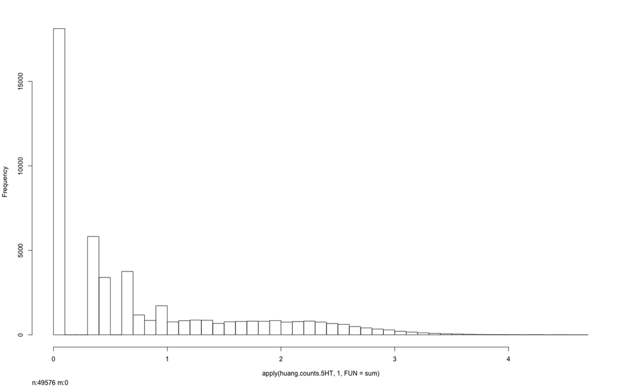

```r
hist(log10(huang.counts.5HT+1), breaks = 100, ylim = c(0, 1000))
```

```r
rm(huang.raw.data)
```

Load the Zeisel count matrix:

```r
library(loomR)
lfile <- connect(filename = "/Volumes/LaCie/Dropbox/Sabatini Lab/DRN Cell Types Project/DRN Cell Types Manuscript/Revisions (1)/RNA-seq/l6_r3_cholinergic_monoaminergic_and_peptidergic_neurons.loom")
zeisel.expr <- t(lfile$matrix[,])
zeisel.genes <- lfile$row.attrs$Gene[]
zeisel.genes.fix <- str_replace(string = zeisel.genes,
                                pattern = "-",
                                replacement = ".")
zeisel.cellIDs <- lfile$col.attrs$CellID[]
zeisel.expr <- as.data.frame(x = zeisel.expr,
                             row.names = zeisel.genes.fix)
colnames(zeisel.expr) <- zeisel.cellIDs
lfile$close_all()
```

Separate the Zeisel 5-HT neurons by rhombomere:

```r
zeisel.cells.r1dr <- WhichCells(object = zeisel.ob.SER,
                                ident = c("R1 (lateral DRN)", "R1 (medial DRN)"))
zeisel.counts.r1dr <- zeisel.expr[,zeisel.cells.r1dr]
dim(zeisel.counts.r1dr)
```

```
[1] 27998   118
```

```r
zeisel.counts.r1dr <- as.data.frame(apply(zeisel.counts.r1dr, 1, FUN = sum),
                                    row.names = rownames(zeisel.expr))
dim(zeisel.counts.r1dr)
```

```
[1] 27998     1
```

```r
zeisel.cells.mrn <- WhichCells(object = zeisel.ob.SER,
                                ident = c("R1/R2 (MRN)"))
zeisel.counts.mrn <- zeisel.expr[,zeisel.cells.mrn]
dim(zeisel.counts.mrn)
```

```
[1] 27998    76
```

```r
zeisel.counts.mrn <- as.data.frame(apply(zeisel.counts.mrn, 1, FUN = sum),
                                    row.names = rownames(zeisel.expr))
dim(zeisel.counts.mrn)
```

```
[1] 27998     1
```

```r
zeisel.cells.r5 <- WhichCells(object = zeisel.ob.SER,
                                ident = c("R5 (RMg)"))
zeisel.counts.r5 <- zeisel.expr[,zeisel.cells.r5]
dim(zeisel.counts.r5)
```

```
[1] 27998   103
```

```r
zeisel.counts.r5 <- as.data.frame(apply(zeisel.counts.r5, 1, FUN = sum),
                                    row.names = rownames(zeisel.expr))
dim(zeisel.counts.r5)
```

```
[1] 27998     1
```

```r
zeisel.cells.r6p <- WhichCells(object = zeisel.ob.SER,
                                ident = c("R6P (ROb/RPa)"))
zeisel.counts.r6p <- zeisel.expr[,zeisel.cells.r6p]
dim(zeisel.counts.r6p)
```

```
[1] 27998    20
```

```r
zeisel.counts.r6p <- as.data.frame(apply(zeisel.counts.r6p, 1, FUN = sum),
                                    row.names = rownames(zeisel.expr))
dim(zeisel.counts.r6p)
```

```
[1] 27998     1
```

```r
head(zeisel.counts.r6p)
```

|  | apply(zeisel.counts.r6p, 1, FUN = sum) |
| --- | --- |
| Pgr15l | 52 |
| Fst | 1 |
| Fxyd5 | 3 |
| Asah2 | 7 |
| Klf14 | 8 |
| Lat2 | 4 |

```r
genes.common <- intersect(rownames(huang.counts.5HT), rownames(zeisel.expr))
length(genes.common)
```

```
[1] 25815
```

```r
head(genes.common)
```

```
[1] "A130010J15Rik" "A130014A01Rik" "A130030D18Rik" "A130051J06Rik" "A1bg"          "A1cf"
```

Combine into a single data matrix:

```r
data.sc.huang <- as.data.frame(huang.counts.5HT[genes.common,])
rownames(data.sc.huang) <- genes.common
data.sc.zeisel <- cbind(zeisel.counts.r1dr[genes.common,],
                        zeisel.counts.mrn[genes.common,],
                        zeisel.counts.r5[genes.common,],
                        zeisel.counts.r6p[genes.common,])
rownames(data.sc.zeisel) <- genes.common
data.sc <- cbind(data.sc.zeisel, data.sc.huang)
colnames(data.sc) <- c("Zeisel_R1DR", "Zeisel_MRN", "Zeisel_R5", "Zeisel_R6P", "Huang_5HT")
dim(data.sc)
```

```
[1] 25815     5
```

```r
corner(data.sc)
```

|  | Zeisel_R1DR | Zeisel_MRN | Zeisel_R5 | Zeisel_R6P | Huang_5HT |
| --- | --- | --- | --- | --- | --- |
| A130010J15Rik | 7 | 8 | 15 | 1 | 51 |
| A130014A01Rik | 4 | 8 | 1 | 0 | 17 |
| A130030D18Rik | 0 | 0 | 0 | 0 | 2 |
| A130051J06Rik | 0 | 0 | 0 | 0 | 4 |
| A1bg | 0 | 0 | 0 | 0 | 0 |

Combine with Okaty et al. (2015) pooled data:

```r
length(intersect(rownames(data.sc), okaty.data$`Gene Symbol`))
```

```
[1] 19366
```

```r
okaty.genes.fixed <- str_replace(string = okaty.data$`Gene Symbol`,
                                pattern = "-",
                                replacement = ".")
length(intersect(rownames(data.sc), okaty.genes.fixed))
```

```
[1] 19488
```

```r
genes.keep <- is.element(okaty.genes.fixed, genes.common)
okaty.data.pooled <- okaty.data[genes.keep, c("Gene Symbol",
                                              "R1 DR #1 Pooled",
                                              "R1 DR #2 Pooled",
                                              "R1 DR #3 Pooled",
                                              "R1 MR #1 Pooled",
                                              "R1 MR #2 Pooled",
                                              "R1 MR #3 Pooled",
                                              "R2 #1 Pooled",
                                              "R2 #2 Pooled",
                                              "R2 #3 Pooled",
                                              "R3 #1 Pooled",
                                              "R3 #2 Pooled",
                                              "R3 #3 Pooled",
                                              "R5 #1 Pooled",
                                              "R5 #2 Pooled",
                                              "R5 #3 Pooled",
                                              "R6P #1 Pooled",
                                              "R6P #2 Pooled",
                                              "R6P #3 Pooled")]
dim(okaty.data.pooled)
```

```
[1] 24678    19
```

```r
head(okaty.data.pooled)
```

| Gene Symbol | R1 DR #1 Pooled | R1 DR #2 Pooled | R1 DR #3 Pooled | R1 MR #1 Pooled | R1 MR #2 Pooled | R1 MR #3 Pooled | R2 #1 Pooled | R2 #2 Pooled | R2 #3 Pooled | R3 #1 Pooled | R3 #2 Pooled | R3 #3 Pooled | R5 #1 Pooled | R5 #2 Pooled | R5 #3 Pooled | R6P #1 Pooled | R6P #2 Pooled | R6P #3 Pooled |
| --- | --- | --- | --- | --- | --- | --- | --- | --- | --- | --- | --- | --- | --- | --- | --- | --- | --- | --- |
| Atraid | 467 | 294 | 120 | 232 | 576 | 400 | 478 | 820 | 1175 | 325 | 288 | 140 | 497 | 541 | 609 | 474 | 303 | 570 |
| Tmem248 | 802 | 1154 | 465 | 436 | 805 | 457 | 1038 | 2453 | 2235 | 362 | 353 | 166 | 862 | 1097 | 1999 | 560 | 494 | 614 |
| Ercc6l2 | 224 | 399 | 98 | 127 | 357 | 307 | 315 | 564 | 762 | 174 | 217 | 146 | 201 | 617 | 327 | 129 | 207 | 185 |
| Ercc6l2 | 91 | 116 | 84 | 65 | 151 | 53 | 79 | 226 | 295 | 88 | 125 | 27 | 55 | 223 | 122 | 55 | 39 | 57 |
| Tsr3 | 355 | 249 | 114 | 476 | 681 | 484 | 416 | 562 | 1411 | 181 | 251 | 302 | 394 | 425 | 752 | 305 | 429 | 576 |
| Tsr3 | 355 | 250 | 114 | 476 | 681 | 484 | 416 | 562 | 1411 | 181 | 251 | 302 | 394 | 425 | 755 | 305 | 434 | 576 |

```r
length(okaty.data.pooled$`Gene Symbol`)
```

```
[1] 24678
```

```r
length(unique(okaty.data.pooled$`Gene Symbol`))
```

```
[1] 19488
```

```r
length(unique(okaty.genes.fixed[genes.keep]))
```

```
[1] 19488
```

Sum counts for genes with multiple annotations:

```r
geneSymbol <- unique(okaty.genes.fixed[genes.keep])
okaty.data.pooled.agg <- matrix(nrow = length(geneSymbol),
                                ncol = length(colnames(okaty.data.pooled))-1)
for (i in 1:length(geneSymbol)) {
  temp <- as.matrix(okaty.data.pooled[okaty.data.pooled$`Gene Symbol`==geneSymbol[i], -1])
  temp <- colSums(temp)
  okaty.data.pooled.agg[i,] <- temp
}
okaty.data.pooled.agg <- as.data.frame(okaty.data.pooled.agg,
                                       row.names = geneSymbol)
colnames(okaty.data.pooled.agg) <- colnames(okaty.data.pooled[,-1])
dim(okaty.data.pooled.agg)
```

```
[1] 19488    18
```

```r
head(okaty.data.pooled.agg)
```

|  | R1 DR #1 Pooled | R1 DR #2 Pooled | R1 DR #3 Pooled | R1 MR #1 Pooled | R1 MR #2 Pooled | R1 MR #3 Pooled | R2 #1 Pooled | R2 #2 Pooled | R2 #3 Pooled | R3 #1 Pooled | R3 #2 Pooled | R3 #3 Pooled | R5 #1 Pooled | R5 #2 Pooled | R5 #3 Pooled | R6P #1 Pooled | R6P #2 Pooled | R6P #3 Pooled |
| --- | --- | --- | --- | --- | --- | --- | --- | --- | --- | --- | --- | --- | --- | --- | --- | --- | --- | --- |
| Atraid | 467 | 294 | 120 | 232 | 576 | 400 | 478 | 820 | 1175 | 325 | 288 | 140 | 497 | 541 | 609 | 474 | 303 | 570 |
| Tmem248 | 802 | 1154 | 465 | 436 | 805 | 457 | 1038 | 2453 | 2235 | 362 | 353 | 166 | 862 | 1097 | 1999 | 560 | 494 | 614 |
| Ercc6l2 | 315 | 515 | 182 | 192 | 508 | 360 | 394 | 790 | 1057 | 262 | 342 | 173 | 256 | 840 | 449 | 184 | 246 | 242 |
| Tsr3 | 710 | 499 | 228 | 952 | 1362 | 968 | 832 | 1124 | 2822 | 362 | 502 | 604 | 788 | 850 | 1507 | 610 | 863 | 1152 |
| Hnf4aos | 0 | 0 | 0 | 0 | 0 | 0 | 0 | 0 | 0 | 0 | 0 | 0 | 0 | 0 | 0 | 0 | 0 | 0 |
| Sf3b6 | 278 | 275 | 118 | 170 | 484 | 428 | 355 | 939 | 1216 | 195 | 64 | 88 | 280 | 280 | 419 | 196 | 408 | 353 |

Sort both data frames by rownames and merge

```r
data.sc.filtered <- data.sc[geneSymbol,]
data.combined <- cbind(data.sc.filtered, okaty.data.pooled.agg)
dim(data.combined)
```

```
[1] 19488    23
```

```r
head(rownames(data.combined))
```

```
[1] "Atraid"  "Tmem248" "Ercc6l2" "Tsr3"    "Hnf4aos" "Sf3b6"
```

```r
colnames(data.combined)
```

```
 [1] "Zeisel_R1DR"     "Zeisel_MRN"      "Zeisel_R5"       "Zeisel_R6P"      "Huang_5HT"
 [6] "R1 DR #1 Pooled" "R1 DR #2 Pooled" "R1 DR #3 Pooled" "R1 MR #1 Pooled" "R1 MR #2 Pooled"
[11] "R1 MR #3 Pooled" "R2 #1 Pooled"    "R2 #2 Pooled"    "R2 #3 Pooled"    "R3 #1 Pooled"
[16] "R3 #2 Pooled"    "R3 #3 Pooled"    "R5 #1 Pooled"    "R5 #2 Pooled"    "R5 #3 Pooled"
[21] "R6P #1 Pooled"   "R6P #2 Pooled"   "R6P #3 Pooled"
```

Save the merged data object as a csv file:

```r
write.table(data.combined,
            file = file.path(wd, "countData_pooled_merged.csv"),
            sep = ',',
            row.names = rownames(data.combined),
            col.names = NA)
```

#### 2.1.2 Normalization

Try using the same normalization method used in Okaty et al. (2015):

```r
library(edgeR)
```

```r
groups <- factor(c(rep("Zeisel", 4), "Huang", rep("Okaty", 18)))
y <- DGEList(counts = data.combined, group = groups)
y <- calcNormFactors(y)
y$samples
```

|  | group | lib.size | norm.factors |
| --- | --- | --- | --- |
| Zeisel_R1DR | Zeisel | 913642 | 1.1235807 |
| Zeisel_MRN | Zeisel | 692910 | 1.1559297 |
| Zeisel_R5 | Zeisel | 890140 | 1.2298843 |
| Zeisel_R6P | Zeisel | 129639 | 1.3127654 |
| Huang_5HT | Huang | 3919851 | 1.3454380 |
| R1 DR #1 Pooled | Okaty | 11384001 | 0.9639640 |
| R1 DR #2 Pooled | Okaty | 17360942 | 0.8671559 |
| R1 DR #3 Pooled | Okaty | 7881051 | 0.8580702 |
| R1 MR #1 Pooled | Okaty | 6743850 | 1.0067411 |
| R1 MR #2 Pooled | Okaty | 13073339 | 0.9766719 |

[output cut: 13 more lines]

Check effective library sizes:

```r
y$samples$lib.size*y$samples$norm.factors
```

```
 [1]  1026550.5   800955.2  1094769.2   170185.6  5273916.7 10973767.6 15054643.3  6762494.6  6789311.2
[10] 12768362.4  9098287.7 19558194.1 34346450.7 38956935.4  5807361.6  5468150.8  5572701.5 11656523.0
[19] 15261931.7 23497663.2  5795790.9  7956902.8  8112860.8
```

Filter genes, keeping only genes with CPM > 1 in at least 3 samples:

```r
keep <- rowSums(cpm(y)>1) >= 3
y <- y[keep,]
dim(y)
```

```
[1] 13335    23
```

Re-compute normalization factors

```r
y <- calcNormFactors(y)
y$samples
```

|  | group | lib.size | norm.factors |
| --- | --- | --- | --- |
| Zeisel_R1DR | Zeisel | 913642 | 1.0913885 |
| Zeisel_MRN | Zeisel | 692910 | 1.1435908 |
| Zeisel_R5 | Zeisel | 890140 | 1.2069304 |
| Zeisel_R6P | Zeisel | 129639 | 1.3192851 |
| Huang_5HT | Huang | 3919851 | 1.2523071 |
| R1 DR #1 Pooled | Okaty | 11384001 | 0.9681600 |
| R1 DR #2 Pooled | Okaty | 17360942 | 0.8775001 |
| R1 DR #3 Pooled | Okaty | 7881051 | 0.8727369 |
| R1 MR #1 Pooled | Okaty | 6743850 | 1.0081940 |
| R1 MR #2 Pooled | Okaty | 13073339 | 0.9835179 |

[output cut: 13 more lines]

Check effective library sizes:

```r
y$samples$lib.size*y$samples$norm.factors
```

```
 [1]   997138.4   792405.5  1074337.0   171030.8  4908857.4 11021534.1 15234229.0  6878084.4  6799108.9
[10] 12857862.9  9080852.4 19517822.0 34407937.6 39262487.9  5866611.8  5585113.7  5657961.4 11766566.3
[19] 15317912.7 23658576.9  5831375.8  7937437.5  8179435.9
```

Check MDS plot:

```
Found more than one class "MDS" in cache; using the first, from namespace 'dimRed'
Also defined by ‘limma’
```

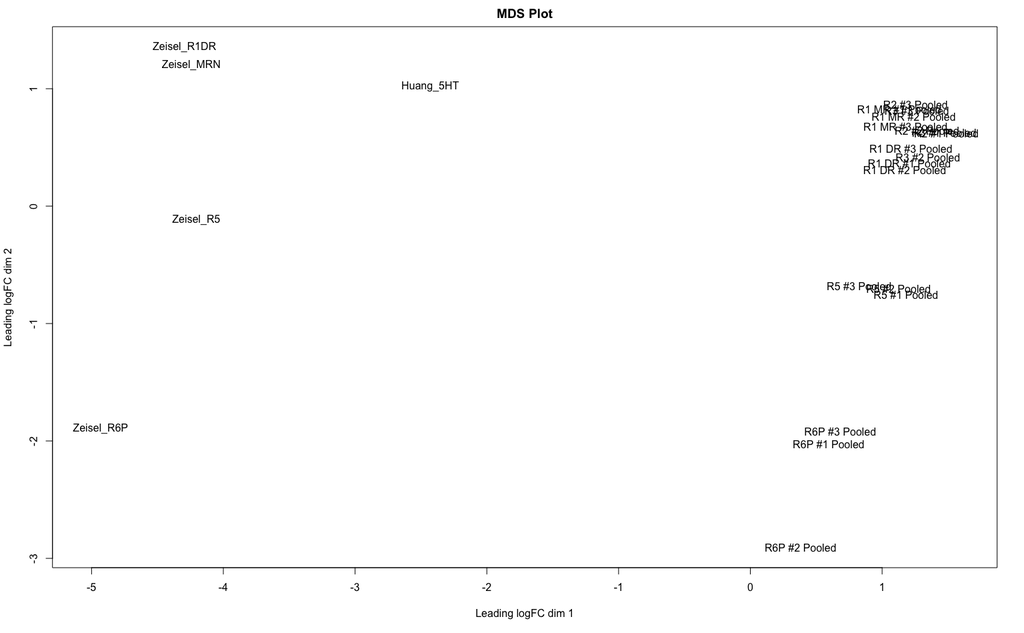

```r
plotMDS(y, main = "MDS Plot")
```

Dimension 1 splits the different datasets, whereas dimension 2 separates the rhombomere groups, where the trend along dim 2 is the same across datasets.

### 2.2 Find DE genes for calculating distance score

Use the filtered Okaty data, thresholding on Q values < 0.05:

```r
okaty.DEgenes <- okaty.data.filtered$`Gene Symbol`[okaty.data.filtered$`FDR (from edgeR DE analysis)`<0.05]
length(okaty.DEgenes)
```

```
[1] 3644
```

```r
head(okaty.DEgenes, 10)
```

```
 [1] "0610010K14Rik" "0610037L13Rik" "1110008P14Rik" "1110012L19Rik" "1110038B12Rik" "1110065P20Rik"
 [7] "1190002N15Rik" "1500009L16Rik" "1500012F01Rik" "1600002H07Rik"
```

```r
tail(okaty.DEgenes, 10)
```

```
 [1] "Zmiz2"  "Zranb2" "Zscan2" "Zswim1" "Zswim6" "Zswim7" "Zwilch" "Zwint"  "Zyg11b" "Zzz3"
```

```r
is.element("En1", okaty.DEgenes)
```

```
[1] TRUE
```

```r
is.element("Slc17a8", okaty.DEgenes)
```

```
[1] TRUE
```

```r
is.element("Slc6a4", okaty.DEgenes)
```

```
[1] TRUE
```

```r
is.element("Fev", okaty.DEgenes)
```

```
[1] TRUE
```

```r
is.element("Actb", okaty.DEgenes)
```

```
[1] FALSE
```

Check similarities between clusters using hierarchical clustering, using CPM values of DE genes:

```r
y.cpm <- cpm(y)
y.cpm.DEgenes <- y.cpm[is.element(rownames(y.cpm), okaty.DEgenes),]
dim(y.cpm.DEgenes)
```

```
[1] 3467   23
```

```r
corner(y.cpm.DEgenes)
```

```
        Zeisel_R1DR Zeisel_MRN Zeisel_R5 Zeisel_R6P Huang_5HT
Atraid     67.19228   39.12138  56.77920    40.9283  37.48326
Tsr3       54.15497   31.54950  29.78581    23.3876  26.89017
Sf3b6      59.16932   31.54950  43.74791    64.3159 161.95215
Glmp       18.05166   18.92970  15.82371     0.0000  27.09388
Cebpzos    87.24968   39.12138  32.57823    52.6221  19.35277
```

```r
y.cpm.DEgenes["Slc6a4",]
```

```
    Zeisel_R1DR      Zeisel_MRN       Zeisel_R5      Zeisel_R6P       Huang_5HT R1 DR #1 Pooled
      3211.1892       2742.2829       2116.6542        385.8954       3674.3785       5335.1919
R1 DR #2 Pooled R1 DR #3 Pooled R1 MR #1 Pooled R1 MR #2 Pooled R1 MR #3 Pooled    R2 #1 Pooled
      6822.2685       7494.5286       2503.1221       3581.0772       3736.3233       2140.4540
   R2 #2 Pooled    R2 #3 Pooled    R3 #1 Pooled    R3 #2 Pooled    R3 #3 Pooled    R5 #1 Pooled
      1809.7859       1545.2918       3073.6651       3568.0563       1822.9180       2502.5143
   R5 #2 Pooled    R5 #3 Pooled   R6P #1 Pooled   R6P #2 Pooled   R6P #3 Pooled
      3687.7087       2395.1145       2746.3502       2862.0068       2887.4852
```

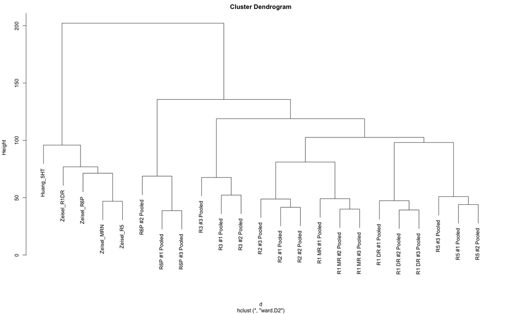

```r
d <- dist(x = scale(t(y.cpm.DEgenes)), method = "euclidean")
hc <- hclust(d, method = "ward.D2")
plot(hc)
```

Clusters split mostly by dataset - probably because there is such a big difference in the library sizes that makes it difficult to normalize the data (artificially pooled scRNA-seq library sizes are much smaller than bulk RNA-seq libraries).

## Session Information

Machine specifications:

- Mac Pro (Late 2013)
- macOS High Sierra 10.13.4
- 3.7 GHz Quad-Core Intel Xeon E5
- 64 GB 1866 MHz DDR3
- Java version “1.8.0_172”

```
 setting  value
 version  R version 3.4.4 (2018-03-15)
 system   x86_64, darwin15.6.0
 ui       RStudio (1.1.447)
 language (EN)
 collate  en_US.UTF-8
 tz       America/New_York
 date     2019-05-18
```

```
Packages ----------------------------------------------------------------------------------------------
```

```
 package       * version    date       source
 abind           1.4-5      2016-07-21 CRAN (R 3.4.0)
 acepack         1.4.1      2016-10-29 cran (@1.4.1)
 ape           * 5.1        2018-04-04 CRAN (R 3.4.4)
 assertthat      0.2.0      2017-04-11 CRAN (R 3.4.0)
 backports       1.1.2      2017-12-13 CRAN (R 3.4.3)
 base          * 3.4.4      2018-03-15 local
 base64enc       0.1-3      2015-07-28 cran (@0.1-3)
 bindr           0.1.1      2018-03-13 CRAN (R 3.4.4)
 bindrcpp        0.2.2      2018-03-29 CRAN (R 3.4.4)
 BiocInstaller * 1.28.0     2017-10-31 Bioconductor
 bit             1.1-14     2018-05-29 CRAN (R 3.4.4)
 bit64           0.9-7      2017-05-08 CRAN (R 3.4.0)
 bitops          1.0-6      2013-08-17 cran (@1.0-6)
 broom           0.4.4      2018-03-29 CRAN (R 3.4.4)
 caret           6.0-80     2018-05-26 CRAN (R 3.4.4)
 caTools         1.17.1     2014-09-10 cran (@1.17.1)
 cellranger      1.1.0      2016-07-27 CRAN (R 3.4.0)
 checkmate       1.8.5      2017-10-24 CRAN (R 3.4.2)
 class           7.3-14     2015-08-30 CRAN (R 3.4.4)
 cli             1.0.0      2017-11-05 CRAN (R 3.4.2)
 cluster         2.0.7-1    2018-04-09 CRAN (R 3.4.4)
 codetools       0.2-15     2016-10-05 CRAN (R 3.4.4)
 colorspace      1.3-2      2016-12-14 CRAN (R 3.4.0)
 compiler        3.4.4      2018-03-15 local
 cowplot       * 0.9.2      2017-12-17 CRAN (R 3.4.3)
 crayon          1.3.4      2017-09-16 CRAN (R 3.4.1)
 CVST            0.2-2      2018-05-26 CRAN (R 3.4.4)
 data.table      1.10.4-3   2017-10-27 CRAN (R 3.4.2)
 datasets      * 3.4.4      2018-03-15 local
 ddalpha         1.3.2      2018-04-08 CRAN (R 3.4.4)
 DEoptimR        1.0-8      2016-11-19 cran (@1.0-8)
 devtools      * 1.13.5     2018-02-18 CRAN (R 3.4.3)
 diffusionMap    1.1-0      2014-02-20 cran (@1.1-0)
 digest          0.6.15     2018-01-28 CRAN (R 3.4.3)
 dimRed          0.1.0      2017-05-04 CRAN (R 3.4.0)
 diptest         0.75-7     2016-12-05 cran (@0.75-7)
 doSNOW          1.0.16     2017-12-13 CRAN (R 3.4.3)
 dplyr         * 0.7.5      2018-05-19 CRAN (R 3.4.4)
 DRR             0.0.3      2018-01-06 CRAN (R 3.4.3)
```

[output cut: 108 more lines]

```
 tclust          1.4-1      2018-05-24 CRAN (R 3.4.4)
 tibble          1.4.2      2018-01-22 CRAN (R 3.4.3)
 tidyr           0.8.1      2018-05-18 CRAN (R 3.4.4)
 tidyselect      0.2.4      2018-02-26 CRAN (R 3.4.3)
 timeDate        3043.102   2018-02-21 CRAN (R 3.4.3)
 tools           3.4.4      2018-03-15 local
 trimcluster     0.1-2      2012-10-29 cran (@0.1-2)
 tsne            0.1-3      2016-07-15 cran (@0.1-3)
 useful        * 1.2.4      2018-05-21 CRAN (R 3.4.4)
 utf8            1.1.4      2018-05-24 CRAN (R 3.4.4)
 utils         * 3.4.4      2018-03-15 local
 VGAM            1.0-5      2018-02-07 CRAN (R 3.4.3)
 withr           2.1.2      2018-03-15 CRAN (R 3.4.4)
 yaml            2.1.19     2018-05-01 CRAN (R 3.4.4)
 zoo             1.8-1      2018-01-08 CRAN (R 3.4.3)
```